# Computational Proteomics Trends 2019.

This jupyter notebook aims to read the data from Google Scholar csv poll into a panda dataframe to perform basic statistics about proteomics software useage by 2019.

- The original poll is not close and you can vote [here](https://goo.gl/forms/WLRSczvs016Vd3673)
- The results are collected in this [Github repo](https://github.com/ypriverol/CompProt2019-paper)

```python
import pandas as pd
#import plotly.plotly as py
import plotly.graph_objs as go
from plotly.offline import download_plotlyjs, init_notebook_mode, plot, iplot
import plotly.plotly as py

init_notebook_mode(connected=True)

# Read the poll data
data_df = pd.read_csv("../data/poll-results-07032019.csv")
data_citations = pd.read_csv("../data/citations-count.csv")
data_df.head()
```

|  | Timestamp | Username | What is your current position? | In what kind of research institute do you work? | Which of these software do you use for your Quant Analysis. [TPP (StPeter, Libra, XPress)] | Which of these software do you use for your Quant Analysis. [OpenMS] | Which of these software do you use for your Quant Analysis. [Other] | Which of these software do you use for your Quant Analysis. [MSnBase (PMID:22113085)] | Which of these software do you use for your Quant Analysis. [moFF] | Which of these software do you use for your Quant Analysis. [FlashLFQ (PMID:29083185)] | ... | Search engine and type of analysis [MSAmanda] | Search engine and type of analysis [Mascot] | Which type of Protein quant data you would like to see more in proteomics resources. (e.g. TPP, ProteomicsDB, etc) [Label-Free Differential expression experiments] | Which type of Protein quant data you would like to see more in proteomics resources. (e.g. TPP, ProteomicsDB, etc) [Label-Free Base line expression experiments] | Which type of Protein quant data you would like to see more in proteomics resources. (e.g. TPP, ProteomicsDB, etc) [TMT Differential expression experiments] | Which type of Protein quant data you would like to see more in proteomics resources. (e.g. PeptideAtlas, ProteomicsDB, etc) [TMT Base line expression experiments] | Which type of Protein quant data you would like to see more in proteomics resources. (e.g. PeptideAtlas, ProteomicsDB, etc) [SRM/MR expression Experiments] | Which type of Protein quant data you would like to see more in proteomics resources. (e.g. PeptideAtlas, ProteomicsDB, etc) [DIA/SWATH expression experiments] | In case you would like to see something else more represented in Proteomics resources let us know. | Unnamed: 66 |
| --- | --- | --- | --- | --- | --- | --- | --- | --- | --- | --- | --- | --- | --- | --- | --- | --- | --- | --- | --- | --- | --- |
| 0 | 2019/02/08 1:42:21 PM GMT | user1 | NaN | NaN | NaN | NaN | NaN | NaN | NaN | NaN | ... | NaN | NaN | NaN | NaN | NaN | NaN | NaN | NaN | NaN | NaN |
| 1 | 2019/02/08 1:49:09 PM GMT | user2 | NaN | NaN | NaN | NaN | NaN | NaN | NaN | NaN | ... | NaN | NaN | NaN | NaN | NaN | NaN | NaN | NaN | NaN | NaN |
| 2 | 2019/02/08 1:54:35 PM GMT | user3 | NaN | NaN | NaN | NaN | NaN | NaN | NaN | NaN | ... | NaN | NaN | NaN | NaN | NaN | NaN | NaN | NaN | NaN | NaN |
| 3 | 2019/02/08 2:13:28 PM GMT | user4 | NaN | NaN | NaN | NaN | NaN | NaN | NaN | NaN | ... | NaN | NaN | NaN | NaN | NaN | NaN | NaN | NaN | NaN | NaN |
| 4 | 2019/02/08 3:22:10 PM GMT | user5 | NaN | NaN | NaN | NaN | NaN | NaN | NaN | Label Free Analysis MS1 | ... | NaN | NaN | NaN | NaN | NaN | NaN | NaN | NaN | NaN | NaN |

5 rows × 67 columns

```python
def get_pie_chart(collection):
    """
    This function returns a pie chart from a collection of elements.
    @param collection must be a column from a pandas datframe
    """

    collection_counts = {}
    for word in collection:
        token_collection = str(word).split(";")
        for token in token_collection:
            if token.strip() != 'nan':
                if token not in collection_counts:
                   collection_counts[token] = 0
                collection_counts[token] = collection_counts[token] + 1


    trace=go.Pie(labels=[k  for  k in  collection_counts.keys()],values=[k  for  k in  collection_counts.values()])
    return trace

def get_multioption_bar_data(data_df, question):
    """
    This function get a panda dataframe and an a multioption question and generate a barplot
    @param data Pandas data frame
    @param question Question (column name prefix)
    """
    column_names = [col for col in data_df.columns if question in col]
    values = []
    for column in column_names:
        value = column[column.find("[") + 1: column.find("]")]
        values.append(value)

    plot_values = {}

    for index, row in data_df.iterrows():
        for column in column_names:
            column_value = column[column.find("[") + 1: column.find("]")]
            complete_value = data_df.at[index,column]
            combined_values = str(complete_value).split(";")
            for value in combined_values:
                if value not in values:
                    if value in plot_values:
                        if column_value in plot_values[value]:
                            count = plot_values[value][column_value] + 1
                            plot_values[value].update({column_value:count})
                        elif ((str(value)).lower() != 'nan'):
                            plot_values[value].update({column_value:1})
                    elif((str(value)).lower() != 'nan'):
                        plot_values[value] = {column_value: 1}

    data = []
    for option in plot_values:
        trace = go.Bar(x = list(plot_values[option].keys()), y = list(plot_values[option].values()),name = option)
        data.append(trace)
    return data

def get_column_distribution(current_data, question):
    """
    This function provides the distribution for one column question.
    """
    downstream_cols = [col for col in current_data.columns if question in col]
    downstream_data = current_data[downstream_cols]

    downstream_dic = {}
    for index, row in downstream_data.iterrows():
        for column in downstream_cols:
            sentence = downstream_data.at[index, column]
            if(str(sentence).lower() != 'nan'):
                values = sentence.split(";")
                for value in values:
                    if value.strip() not in downstream_dic:
                       downstream_dic[value.strip()] = 0
                    downstream_dic[value.strip()] = downstream_dic[value.strip()] + 1

    data = [go.Bar(
           x=list(downstream_dic.values()),
           y=list(downstream_dic.keys()),
           orientation = 'h'
     )]
    return data
```

## Position Distribution

Read the position and occupation of every participant of the poll.

```python
positions = data_df.iloc[:,2]
trace = get_pie_chart(positions)
iplot([trace])
```

[interactive chart not shown]

## Affiliation distribtuion

The number of participants in the poll by type of Institution.

```python
affiliations = data_df.iloc[:,3]
trace = get_pie_chart(affiliations)
iplot([trace])
```

[interactive chart not shown]

## Which of these software do you use for your Quant Analysis

These plots will show the usage of Quantification software.

```python
question = "Which of these software do you use for your Quant Analysis"
data = get_multioption_bar_data(data_df, question)
layout = go.Layout(barmode='group')
fig = go.Figure(data=data, layout=layout)
iplot(fig, filename='grouped-bar')
```

[interactive chart not shown]

## Which commercial software do you use for your Quant Analysis

These plots will show the usage of Quantification software (Commercial software).

```python
question = "Which commercial software do you use for your Quant Analysis"
data = get_multioption_bar_data(data_df, question)
layout = go.Layout(barmode='group')
fig = go.Figure(data=data, layout=layout)
iplot(fig, filename='grouped-bar')
```

[interactive chart not shown]

## Relevant software features during the selection process

The purpose of this question is to know, whta kind of features the users of Computational proteomics software consider more relevant.

```python
question = "Which are the features that make you to chose the following software for your data analysis"
data = get_multioption_bar_data(data_df, question)
layout = go.Layout(barmode='group',legend=dict(x=1, y=1.0, font=dict(
            family='sans-serif',
            size=10,
            color='#000'
        ),))
fig = go.Figure(data=data, layout=layout)
iplot(fig, filename='grouped-bar')
```

[interactive chart not shown]

## Packages and tools use for downstream analysis

This section shows the software/tools and packages (Python and R) for downstream analysis.

```python
# We use a filter here because of special characters
question_pattern = "Which packages do you use for downstream analysis"
data = get_column_distribution(data_df, question_pattern)
iplot(data, filename='horizontal-bar')
```

[interactive chart not shown]

## Peptide/Protein identification Search engines

This part of the poll is about the usage of Peptide/protein search engines.

```python
question="Which Search engine free do you use"
data = get_column_distribution(data_df, question)
iplot(data, filename='horizontal-bar')
```

[interactive chart not shown]

## Search Engine by Type of Analysis

This questions aims to detect what type of analysis is performed with each Search Engine.

```python
question = "Search engine and type of analysis"
data = get_multioption_bar_data(data_df, question)
layout = go.Layout(barmode='group')
fig = go.Figure(data=data, layout=layout)
iplot(fig, filename='grouped-bar')
```

[interactive chart not shown]

## Number of citations per Tool (GoogleScholar)

This plot aims to compute the number of citations (Google Scholar) per tool. For the present statistics we added all the main publications related with the tool.

**note**: Please review the file (software-ids.csv) to included all the publications and check if something is missing. You can also add an issue in the repository.

```python
data = [go.Bar(
            x=list(data_citations['Citations']),
            y=list(data_citations['Software']),
            orientation = 'h'
)]

iplot(data, filename='horizontal-bar')
```

[interactive chart not shown]

## Number of Cintations per year (Web of Science)

**note**: In this case the number of citations has been obtained from the web of science. This is the main reason why the `final` numbers between both sections do not match.

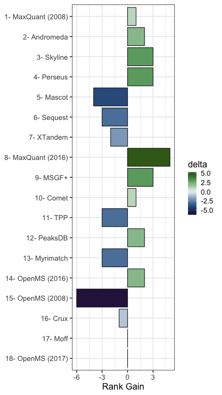

```python
## Note, this code hasn't been implemented yet nativelly in the jupyter notebook. At the moment this figure
## is generated with an external script in the same repository.

from IPython.display import Image
Image("citations_rank_delta.png")
```

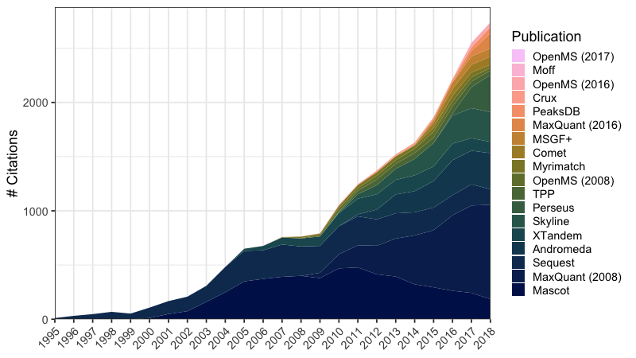

```python
from IPython.display import Image
Image("citations_cumulative.png")
```